# Etude Statistique : Recherche de points influents et atypiques

Dans ce document, nous nous intéressons à l’étude statistique de la recherche de points influents et atypiques de l’IMG. En identifiant ces points, nous pouvons comprendre les patterns et les comportements inhabituels des observations. Et ainsi, éviter le biais des résultats de l’étude.

## Introduction : Indice de Masse Grasse

L’Indice de Masse Grasse (IMG) est un indice, exprimé en pourcentage, permettant de juger de la proportion de tissus adipeux d’une personne adulte, qui rend compte de la disproportion entre la masse de graisse et celles des muscles. De nombreuses méthodes existent permettantd’estimer la proportion de masse adipeuse dans le corps humain. Nous allons nous intéresser plus particulièrement à deux façons de calculer cet indice chez l’adulte :

- 1. La formule proposée par Brozek est : $IMG = \frac{457}{densité_corporelle} − 414.2$
- 2. La formule proposée par Siri est : $IMG = \frac{495}{densité_corporelle} − 450$

On cherchera donc à expliquer les deux variables :

1. body.fat : obtenu à l’aide de la fomule de Brozek.
2. body.fat.siri : obtenu à l’aide de la fomule de Siri.

## Présentation des données

Le jeu de données est `fat` de la library `UsingR` Un traitement a été effectué sur le jeu de données. Les variables ffweight, case et BMI ont été retirées. Le poids a été converti en kilo et la hauteur en centimètre.

Il y a 252 observations et 16 variables.

Variables and Description

| variable | description |
| --- | --- |
| body.fat | Pourcentage de masse grasse en utilisant la formule de Brozek |
| body.fat.siri | Pourcentage de masse grasse en utilisant la formule de Siri |
| density | Densité corporelle |
| age | Age |
| weight | Poids |
| height | Taille |
| neck | Circonférence du cou |
| chest | Circonférence de la poitrine |
| abdomen | Circonférence de l’abdomen ‘du nombril au niveau de la crête iliaque’ |
| hip | Circonférence de la hanche |
| thigh | Circonférence de la cuisse |
| knee | Circonférence du genou |
| ankle | Circonférence de la cheville |
| bicep | Circonférence du biceps à plat (non contracté) |
| forearm | Circonférence de l’avant-bras |
| wrist | Circonférence du poignet ‘de l’extrémité distale du radius au processus styloïde du cubitus’ |

```r
n = 252
```

## Nettoyage des données

Nous allons calculer les IMC avec la densité et enlever les observations pour lesquelles on ne trouve pas les mêmes valeurs.

On enlève les observation pour lesquelles il y a une différence.

Nous allons réaliser des statistiques descriptives univariées pour vérifier si il y a des valeurs aberrantes. Il est possible de visualiser les outliers avec des boxplots.

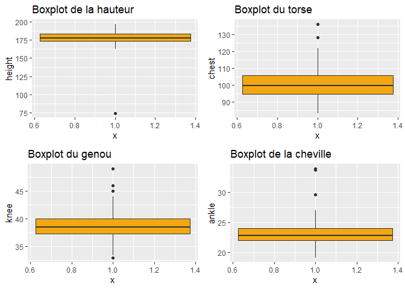

```
## # A tibble: 1 x 18
##    case body.fat body.fat.siri density   age weight height   BMI  neck chest
##   <int>    <dbl>         <dbl>   <dbl> <int>  <dbl>  <dbl> <dbl> <dbl> <dbl>
## 1    42     31.7          32.9    1.02    44   93.0   74.9  29.9  36.6   106
## # ... with 8 more variables: abdomen <dbl>, hip <dbl>, thigh <dbl>, knee <dbl>,
## #   ankle <dbl>, bicep <dbl>, forearm <dbl>, wrist <dbl>
```

Dans les autres boxplots, on peut voir qu’il existe des individus atypiques. Cependant, on ne les enlève pas car on ne sait pas si ils sont influents. C’est ce que l’on abordera dans la partie suivante.

Après toutes ces modifications, on a maintenant une population de :

```r
n = 202
```

## Détections des points influents ou atypiques

Dans un premier temps, on souhaite identifier les observations qui peuvent fausser les résultats de la régression. Cela consiste à détecter les points influents ou atypiques.

On va réaliser le modèle complet avec X = body.fat, soit l’IMG de Brozek.

Le modèle s’écrit matriciellement:

${Y = X \theta } \quad {+} \quad {\epsilon}$

Ecriture du modèle complet : Modèle M$_{p+1}$ où $p=13$

$${Y_i = \beta + \sum_{j=1}^{p} +
\alpha_jx_{i,j} + \epsilon_i, \quad \epsilon_i \quad iid \quad suit
\quad une \quad loi \quad {N(0,\sigma²)}}$$

Sous R :

```r
Model14S = lm(body.fat ~ age + weight + height + neck + chest + abdomen + hip + thigh + knee + ankle + bicep + forearm + wrist)
```

#### Graphiques des résidus standardisés et studentisés

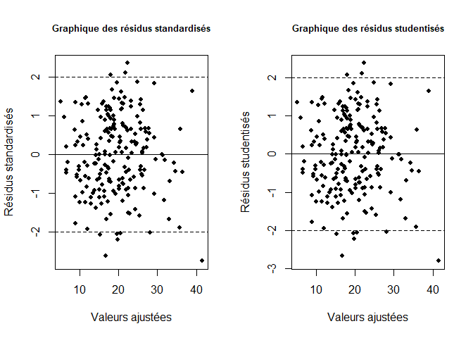

Nous allons réaliser toutes les méthodes manuellement, puis conclure en reprenant toutes les méthodes avec la fonction influence.measure().

Les méthodes :

- les points leviers
- la distance de Cook
- l’écart de Welsh-Ku, DFFITS
- les DFBETA

#### Les points leviers

Pour une observation i, $h_{ii}$ est la distance avec le centre de gravité du nuage de points dans l’espace défini par les variables explicatives

Théoriquement, un point levier est un $h_{ii}$ grand. Cela veut dire que si un point i dépasse un seuil prédéfini, celui-ci devient un point levier.

Nous pouvons comparer $h_{ii}$ à trois seuils :

- Le seuil d’Huber (1981)
- Le seuil de Velleman & Welsh (1981)
- Le seuil d’Hoaglin & Welsch (1978)

Un point levier est une observation qui ne peut pas être prédite comme les autres observations. Le point levier n’est pas nécessairement influent. Si les observations sont des points leviers et présentent des résidus importants, elles sont susceptibles d’être influentes.

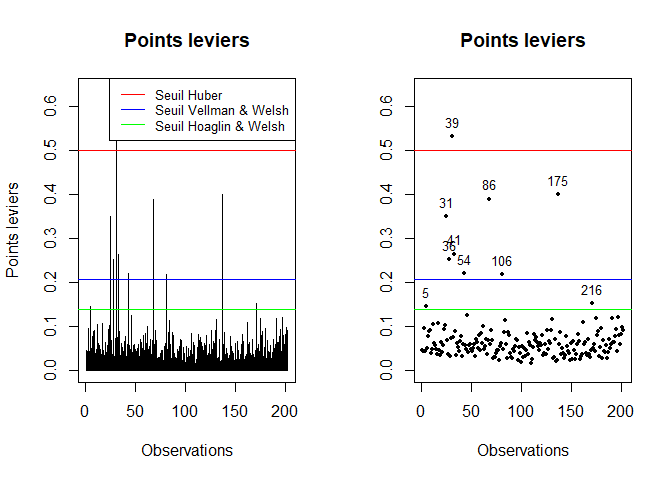

Avec le seuil d’Huber, le point 31 est un point levier.

Avec le seuil de Velleman & Welsh, les points 31, 25, 28, 33, 43, 68, 81, 137 sont des points leviers.

Avec le seuil d’Hoaglin & Welsch, les points 5, 31, 25, 28, 33, 43, 68, 81, 137, 171 sont des points leviers.

Nous allons réaliser le calcul de la distance entre l’observation et la moyenne, l’analyse des résidus pour vérifier ces hypothèses.

#### La distance de Cook

La distance de Cook mesure l’influence de l’observation i sur l’estimation des paramètres $\theta$. Elle mesure deux caractères : le caractère aberrant et le caractère levier. Il est reccomandé de supprimer les observations avec une forte distance de Cook.

Nous allons utiliser le seuil : $\frac{4}{n-p-1}$

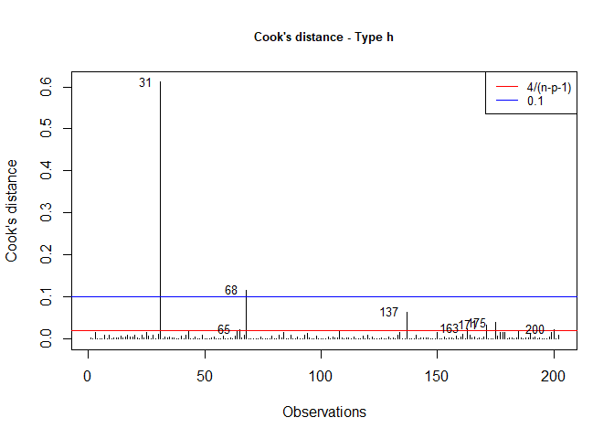

Nous avons les points 31, 68, 65, 137, 175, 171, 163 et 200.

Le graphique **“Residuals vs Leverage”** ci-dessous va permettre d’identifier les observations influentes dans le modèle de régression multiple. Chaque point est une observation. L’axe x représente le levier, c’est-à-dire qu’elle montre l’ampleur de la modification des coefficients du modèle si une observation spécifique était retirée. L’axe y représente les résidus standardisés, soit la différence standardisée entre une valeur prédite et la valeur réelle pour une même observation.

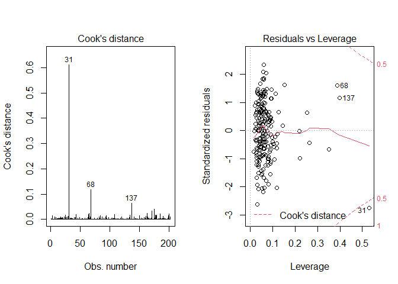

`Interprétation` : Selon R, les observations #68 et #137 sont atypiques. L’observation #31 sort de la distance de Cook. Elle dépasse la ligne rouge, alors elle est influente.

#### L’écart de Welsh-Ku, aussi appelé DFFITS

Le DFFITS est calculé en comparant les valeurs ajustées du modèle lorsque l’observation est incluse ou non du modèle. Une grande distance entre les deux valeurs suggère que l’observation a une influcence importante sur les prédictions du modèle.

L’écart de Welsh-Kuh est défini par :

$$Wk_i =
|t_i^*|\sqrt{\frac{h_{ii}}{1-h_{ii}}}$$
Le seuil est $2 \times \sqrt{\frac{p}{n}}$ :

```
## [1] 0.5073714
```

Les observations ayant un DFFITS supérieur au seuil sont :

```
##         31         43         64         65         68        108        137
## -2.9774356 -0.5206605  0.5174007  0.5736590  1.2855655 -0.5322809  0.9535534
##        163        171        175        185        200
##  0.5965195  0.6960672 -0.7501383 -0.5507515 -0.5699092
```

#### DFBETA

Le DFBETA est calculé en comparant les coefficients de régression lorsque l’observation est incluse et excluse du modèle.

Si le DFBETA est supérieur au seuil, cela signifie que l’observation à une influence significative sur la variable.

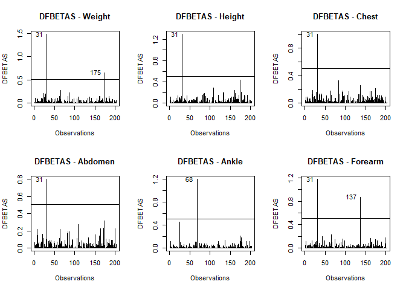

Les observations n’ont pas d’influences sur les variables age, neck, hip, thigh, knee, bicep et wrist.

#### La fonction influence.measures() de R

La fonction influence.measures() calcule les mesures d’influences selon différentes méthodes pour chaque points. En la combinant à la fonction summary(), on obtient les points influents.

La fonction influcence.measures() donne les mêmes indicateurs mais on aura pas les mêmes résultats car ce ne sont pas les mêmes seuils.

- DFFITS (seuil = 3p(p + 1)/(n − p − 1).)
- DFBETA (seuil = 1).
- les distances de Cook,
- les hii (seuil = 3(p + 1)/n))

Les observations influentes sont :

```r
rownames(infl_values)
```

```
##  [1] "5"   "25"  "28"  "31"  "33"  "43"  "68"  "81"  "137" "163" "178" "197"
```

#### Récapitulatif

`Résumé` :

Nous devons comprendre pourquoi ces observations sont différentes. Nous devons voir si les résidus de ces observations sont suffisament élevés. Même si elles ne sont pas influentes, auront-elles un impact sur la validité du modèle ?

Déja, nous pouvons enlever le #31 car il est influent avec toutes les méthodes. Pour en savoir plus sur les autres observations, nous pouvons analyser les résidus et voir l’impact sur les variances et covariances des $\theta$.

##### Analyse des résidus

Nous allons refaire le graphique des résidus standardisés mais cette fois avec une étiquette pour identifier les observations.

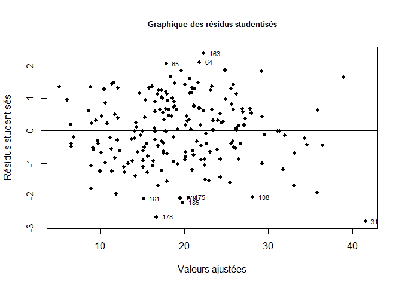

On note les points suivants : 31, 65, 64, 108, 161, 163, 175, 178, 179, 185.

##### Ratio de covariance

Voici les ratios de covariance pour chaque observation i, mesurant l’impact de i sur les variances et covariances des $\theta$.

```r
summary(ModeleInflu)
```

```
## Potentially influential observations of
##   lm(formula = body.fat ~ age + weight + height + neck + chest +      abdomen + hip + thigh + knee + ankle + bicep + forearm +      wrist) :
##
##     dfb.1_  dfb.age dfb.wght dfb.hght dfb.neck dfb.chst dfb.abdm dfb.hip
## 5    0.01   -0.03    0.00     0.00    -0.03    -0.02     0.04    -0.02
## 25   0.13    0.03    0.12    -0.11    -0.11    -0.06    -0.04    -0.04
## 28  -0.15   -0.02   -0.20     0.05     0.02     0.16     0.01     0.26
## 31  -1.20_* -0.45   -1.48_*   1.30_*  -0.33     1.00_*   0.80    -0.23
## 33   0.04    0.01    0.02     0.01     0.05    -0.04     0.01    -0.10
## 43   0.09    0.04    0.10    -0.14     0.13    -0.03    -0.05    -0.02
## 68   0.02    0.37   -0.01    -0.12     0.00    -0.02    -0.06     0.03
## 81   0.00    0.00    0.00     0.00     0.01     0.00     0.00     0.00
## 137 -0.13   -0.24   -0.13     0.08     0.09     0.26    -0.05    -0.02
## 163 -0.01   -0.07   -0.15    -0.19     0.27    -0.03     0.01     0.22
## 178 -0.10   -0.28   -0.03     0.03     0.03     0.00     0.08     0.00
```

[output cut: 27 more lines]

Les observations pour lesquels les valeurs de cov.r se situent en dehors de l’intervalle $[1 − \frac{3p}{n}; 1 + \frac{3p}{n}]$ :

- 5, 25, 28, 31, 33, 43, 68, 81, 137, 163, 178, et 197

## Modèles de régression linéaire multiple

```r
n = 186
```

```r
data <- data %>% select(-density)
```

### Matrice de corrélation

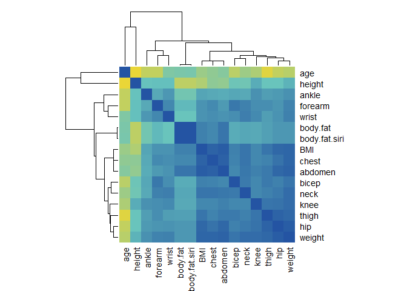

```
##               bd. b.. ag wg hg B n c ab hp t k an bc f wr
## body.fat      1
## body.fat.siri 1   1
## age                   1
## weight        ,   ,      1
## height                   .  1
## BMI           ,   ,      +     1
## neck          .   .      +  .  + 1
## chest         ,   ,      +     * + 1
## abdomen       +   +      +     * , * 1
## hip           ,   ,      *  .  + , + +  1
## thigh         .   .      +  .  + , , ,  +  1
## knee          .   .      +  .  , , , ,  +  + 1
## ankle         .   .      ,  .  . . . .  .  . , 1
## bicep         .   .      +  .  , , , ,  ,  , , .  1
## forearm       .   .      ,  .  , , , .  ,  , , .  ,  1
## wrist         .   .      ,  .  , , , ,  ,  . , ,  ,  , 1
## attr(,"legend")
## [1] 0 ' ' 0.3 '.' 0.6 ',' 0.8 '+' 0.9 '*' 0.95 'B' 1
```

Très corrélés (entre 0,90 et 0,95) :

- hip et weight
- abdomen et chest

Corrélés (entre 0,80 et 0,90) :

- neck et weight
- chest et weight, chest et neck
- abdomen et body.fat, abdomen et body.fat.siri, abdomen et weight
- hip et chest, hip et abdomen
- thigh et weight, thigh et hip
- knee et weight, knee et hip, knee et weight
- bicep et weight

### Equation de Brozek

#### Construction du modèle complet

```r
Modelbrozek = lm(body.fat ~ age + weight + height + neck + chest + abdomen + hip + thigh + knee + ankle + bicep + forearm + wrist)
```

#### Qualité d’ajustement

Le coefficiente de détermination R² (0.75) représente la part de variance de Y expliquée par la régression linéaire, d’après celui-ci l’ajustement du modèle aux données est bon.

```
## [1] 0.7495438
```

Le coefficiente de détermination R² ajusté (0.73) représente la part de variance corrigée de Y expliquée par la régression linéaire, d’après celui-ci l’ajustement est bon.

```
## [1] 0.730614
```

#### Contribution globale des variables explicatives sur body.fat

Modèle linéaire constant

```r
Model1=lm(body.fat~1)
```

Il s’agit d’effecter le test de Fischer de comparaison de modèles. Dans ce cas on a p = 13 et n = 186.

**Hypothèses du test :**  
(H0) : Modèle M1 contre (H1) : Modèle M11

**Statistique de test sous H0 :**
$$F_n = \frac{(SCR(M1) -
SCR(M11))/p}{SCR(M11)/(n-p-1)} \sim^{H_0} F(p, n-p-1)$$

**Règle de décision (quantile) :**

D’après la sortie de “summary(Model14B)”, la statistique de test de Fisher équivaut à 39.6

```r
qf(0.95,13,n-p-1)
```

```
## [1] 1.777434
```

Comme le quantile théorique à 95% d’une F(13,172) vaut 1.78 alors on a fn > 1.78. Par conséquent H0 est rejetée.

#### 1. Méthodes exhaustives de sélections de variable

##### Critère du R²

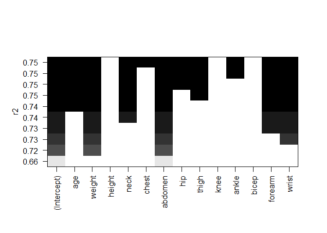

```r
plot(leaps,scale="r2")
```

R2 = 0.75, on garde 7 variables : age, weight, neck, abdo, thigh, forearm et wrist

##### Critère du R² ajusté

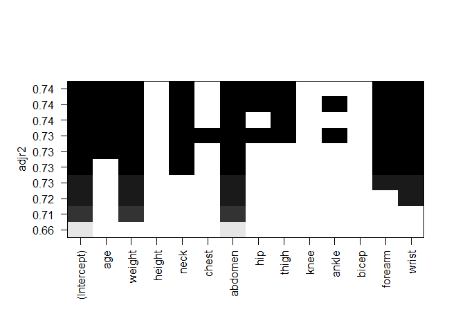

```r
plot(leaps,scale="adjr2")
```

R2 ajusté = 0.74 on garde 7 aussi variables : age, weight, neck, abdomen, thigh, forearm et wrist

##### Critère du Cp de Mallows

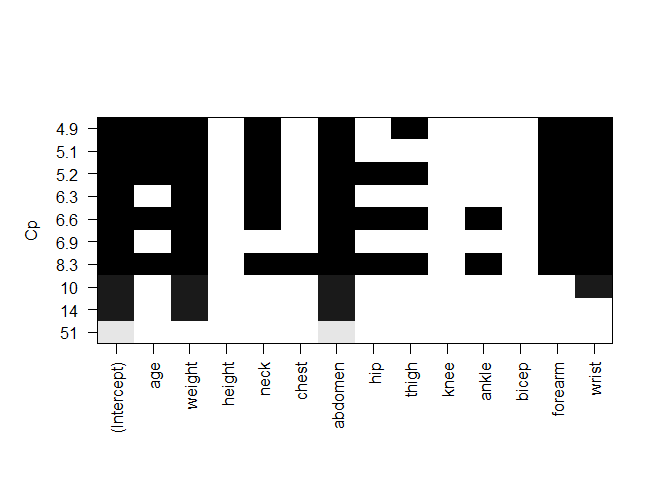

```r
plot(leaps,scale="Cp")
```

Pour 5.1%, nous pouvons garder 6 variables : age, weight, neck, abdo, forearm et wrist

##### Résumé

- **critère du R²** : age, weight, neck, abdo, thigh, forearm et wrist
- **critère du R² ajusté** : age, weight, neck, abdomen, thigh, forearm et wrist
- **critère du Cp de Mallows** : age, weight, neck, abdo, forearm et wrist

#### 2. Méthodes pas à pas de sélections de variable

##### Sélection ascendante test de Fischer

##### Sélection ascendante critère AIC

##### Sélection ascendante critère BIC

##### Sélection descendante avec test de Fischer

##### Sélection descendante avec critère AIC

##### Sélection descendante avec critère BIC

##### Sélection stepwise avec critère AIC départ M1

##### Sélection stepwise avec critère AIC départ M13

##### Sélection stepwise avec critère BIC départ M1

##### Sélection stepwise avec critère BIC départ M13

##### Résumé

**Sélection ascendante :**

- Critère : Fischer —> weight + abdomen + wrist + forearm
- Critère : AIC —> abdomen + weight + wrist + forearm + neck + age + thigh
- Critère : BIC —> abdomen + weight + wrist + forearm

**Sélection descendante :**

- Critère : Fischer —> age + weight + neck + abdomen + thigh + forearm + wrist
- Critère : AIC —> weight + abdomen + forearm + wrist
- Critère : BIC —> age + weight + neck + abdomen + forearm + wrist

**Sélection stepwise :**

- Départ M1 : Critère AIC —> abdomen + weight + wrist + forearm + neck + age + thigh
- Départ M13 : Critère AIC —> age + weight + neck + abdomen + thigh + forearm + wrist
- Départ M1 : Critère BIC —> abdomen + weight + wrist + forearm
- Départ M13 : Critère BIC —> weight + abdomen + forearm + wrist

#### Modèles retenus

Nous retenons les 3 modèles suivants :

- age + weight + neck + abdo + thigh + forearm + wrist
- weight + abdomen + wrist + forearm
- age + weight + neck + abdo + forearm + wrist

Comment choisir le meilleur modèle parmi ces modèles ?

```r
Modelbrozek8 = lm(body.fat ~ age + weight + neck + abdomen + thigh + forearm + wrist)
Modelbrozek5 = lm(body.fat ~ weight + abdomen + wrist + forearm)
Modelbrozek7 = lm(body.fat ~ age + weight + neck + abdomen + forearm + wrist)
```

En comparant tout les summary, on s’aperçoit que Model5 prend la plus grande valeur pour la réalisation de la statistique de test Fn.

**Colinéarité**

```r
vif(Modelbrozek5)
```

```
##   weight  abdomen    wrist  forearm
## 7.719729 5.188320 2.509721 2.510942
```

```r
vif(Modelbrozek8)
```

```
##       age    weight      neck   abdomen     thigh   forearm     wrist
##  2.254336 14.944074  4.783414  8.387001  5.422243  2.868152  3.592585
```

```r
vif(Modelbrozek7)
```

```
##       age    weight      neck   abdomen   forearm     wrist
##  1.961407 13.091970  4.777271  7.997493  2.837846  3.580616
```

Pour Model5, les variables ne sont pas colinéaires aux autres variables. Pour Model7, weight est colinéaire aux autres variables car VIF > 10. Pour Model8, weight est colinéaire aux autres variables car VIF > 10.

Comme le VIF est faibles avec le Model5, on peut espérer trouver un bon modèle explicatif avec celui-ci.

#### Modèle final

```r
ModelFinaleBrozek = lm(body.fat ~ weight + abdomen + wrist + forearm)
```

#### Validation du modèle

**Diagnostic des résidus**

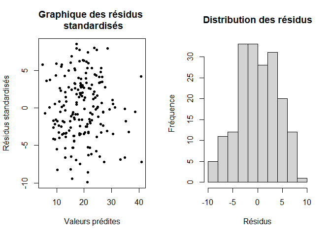

On observe que les résidus sont uniformément dispersés. Les résidus suivent une distribution normale. Le test de schapiro ci-dessous confirme cette affirmation car la p-valeur est supérieur à 0.05.

```
##
##  Shapiro-Wilk normality test
##
## data:  resid(ModelFinaleBrozek)
## W = 0.98906, p-value = 0.1637
```

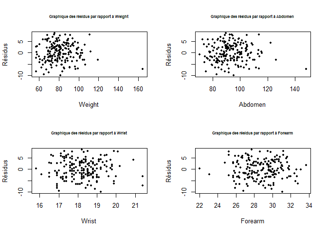

Il n’y a pas non plus de problèmes avec l’étude des résidus par rapport aux variables explicatives du modèle.

#### Nouvelle détection des points influents

```
## Potentially influential observations of
##   lm(formula = body.fat ~ weight + abdomen + wrist + forearm) :
##
##     dfb.1_ dfb.wght dfb.abdm dfb.wrst dfb.frrm dffit   cov.r   cook.d  hat
## 24   0.00   0.02    -0.03     0.03    -0.02    -0.04    1.15_*  0.00    0.10_*
## 27  -0.65  -1.48_*   0.51    -0.11     1.51_*  -2.17_*  1.60_*  0.92_*  0.45_*
## 29   0.15   0.03    -0.08    -0.13     0.03    -0.23    1.09_*  0.01    0.08
## 117 -0.02   0.04    -0.06    -0.02     0.07     0.12    1.09_*  0.00    0.06
## 146 -0.05  -0.01    -0.04     0.10    -0.04    -0.13    1.11_*  0.00    0.08
## 159  0.41   0.48    -0.31    -0.24    -0.24    -0.53_*  0.96    0.06    0.06
## 162 -0.11   0.10    -0.07     0.10    -0.03    -0.30    0.90_*  0.02    0.02
## 163  0.35   0.28    -0.14    -0.18    -0.26    -0.43    0.89_*  0.04    0.03
## 164  0.02   0.00     0.00     0.00    -0.02     0.02    1.11_*  0.00    0.08
## 186 -0.24  -0.13     0.11     0.27    -0.08     0.31    1.08_*  0.02    0.08_*
```

### Equation de Siri

#### Construction du modèle complet

```r
Modelsiri = lm(body.fat.siri ~ age + weight + height + neck + chest + abdomen + hip + thigh + knee + ankle + bicep + forearm + wrist)
```

#### Qualité d’ajustement

Le coefficiente de détermination R² (0.75) représente la part de variance de Y expliquée par la régression linéaire, d’après celui-ci l’ajustement du modèle aux données est bon.

```
## [1] 0.7476626
```

Le coefficiente de détermination R² ajusté (0.73) représente la part de variance corrigée de Y expliquée par la régression linéaire, d’après celui-ci l’ajustement est bon.

```
## [1] 0.7285905
```

#### Contribution globale des variables explicatives sur body.fat

Modèle linéaire constant

```r
Model1=lm(body.fat.siri~1)
```

Il s’agit d’effecter le test de Fischer de comparaison de modèles. Dans ce cas on a p = 13 et n = 186.

**Hypothèses du test :**  
(H0) : Modèle M1 contre (H1) : Modèle M11

**Statistique de test sous H0 :**
$$F_n = \frac{(SCR(M1) -
SCR(M11))/p}{SCR(M11)/(n-p-1)} \sim^{H_0} F(p, n-p-1)$$

**Règle de décision (quantile) :**

D’après la sortie de “summary(Model14S)”, la statistique de test de Fisher équivaut à 39.2

```r
qf(0.95,13,n-p-1)
```

```
## [1] 1.777434
```

Comme le quantile théorique à 95% d’une F(13,172) vaut 1.78 alors on a fn > 1.78. Par conséquent H0 est rejetée.

#### 1. Méthodes exhaustives de sélections de variable

##### Critère du R²

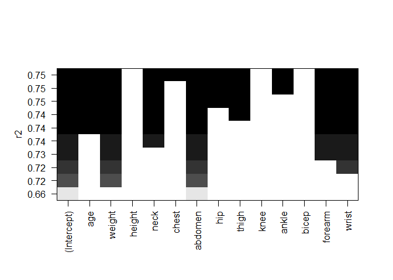

```r
plot(leaps,scale="r2")
```

R2 = 0.74, on garde 6 variables : age, weight, neck, abdo, forearm et wrist

##### Critère du R² ajusté

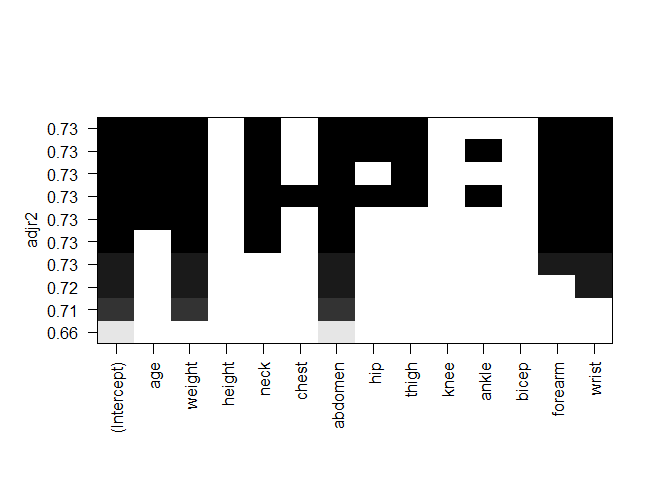

```r
plot(leaps,scale="adjr2")
```

R2 ajusté = 0.73 on garde 5 variables : weight, neck, abdomen, forearm et wrist

##### Critère du Cp de Mallows

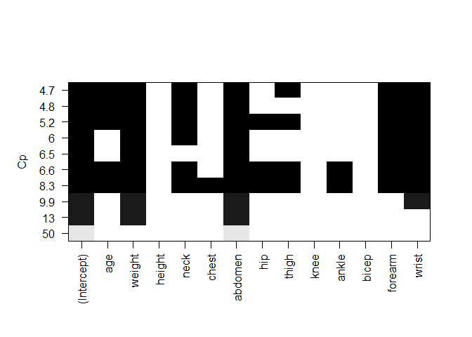

```r
plot(leaps,scale="Cp")
```

Pour 4.8%, nous pouvons garder 6 variables : age, weight, neck, abdo, forearm et wrist

##### Résumé

- **critère du R²** : age, weight, neck, abdo, forearm et wrist
- **critère du R² ajusté** : weight, neck, abdomen, forearm et wrist
- **critère du Cp de Mallows** : age, weight, neck, abdo, forearm et wrist

#### 2. Méthodes pas à pas de sélections de variable

##### Sélection ascendante test de Fischer

##### Sélection ascendante critère AIC

##### Sélection ascendante critère BIC

##### Sélection descendante avec test de Fischer

##### Sélection descendante avec critère AIC

##### Sélection descendante avec critère BIC

##### Sélection stepwise avec critère AIC départ M1

##### Sélection stepwise avec critère AIC départ M13

##### Sélection stepwise avec critère BIC départ M1

##### Sélection stepwise avec critère BIC départ M13

##### Résumé

**Sélection ascendante :**

- Critère : Fischer —> weight + abdomen + wrist + forearm
- Critère : AIC —> abdomen + weight + wrist + forearm + neck + age + thigh
- Critère : BIC —> abdomen + weight + wrist + forearm

**Sélection descendante :**

- Critère : Fischer —> age + weight + neck + abdomen + forearm + wrist (bis : weight + abdomen + forearm + wrist)
- Critère : AIC —> age + weight + neck + abdomen + thigh + forearm + wrist
- Critère : BIC —> weight + abdomen + forearm + wrist

**Sélection stepwise :**

- Départ M1 : Critère AIC —> abdomen + weight + wrist + forearm + neck + age + thigh
- Départ M13 : Critère AIC —> age + weight + neck + abdomen + thigh + forearm + wrist
- Départ M1 : Critère BIC —> abdomen + weight + wrist + forearm
- Départ M13 : Critère BIC —> weight + abdomen + forearm + wrist

#### Modèles retenus

Nous retenons les 3 modèles suivants :

- age + weight + neck + abdo + forearm + wrist
- weight + abdomen + wrist + forearm
- age + weight + neck + abdomen + thigh + forearm + wrist

Comment choisir le meilleur modèle parmi ces modèles ?

```r
Modelsiri5 = lm(body.fat.siri ~ weight + abdomen + wrist + forearm)
Modelsiri7 = lm(body.fat.siri ~ age + weight + neck + abdomen + forearm + wrist)
Modelsiri8 = lm(body.fat.siri ~ age + weight + neck + abdomen + thigh + forearm + wrist)
```

En comparant tout les summary, on s’aperçoit que Model5 prend la plus grande valeur pour la réalisation de la statistique de test Fn.

**Colinéarité**

```r
vif(Modelsiri5)
```

```
##   weight  abdomen    wrist  forearm
## 7.719729 5.188320 2.509721 2.510942
```

```r
vif(Modelsiri8)
```

```
##       age    weight      neck   abdomen     thigh   forearm     wrist
##  2.254336 14.944074  4.783414  8.387001  5.422243  2.868152  3.592585
```

```r
vif(Modelsiri7)
```

```
##       age    weight      neck   abdomen   forearm     wrist
##  1.961407 13.091970  4.777271  7.997493  2.837846  3.580616
```

Pour Model5, les variables ne sont pas colinéaires aux autres variables. Pour Model7, weight est colinéaire aux autres variables car VIF > 10. Pour Model8, weight est colinéaire aux autres variables car VIF > 10.

Comme le VIF est faibles avec le Model5, on peut espérer trouver un bon modèle explicatif avec celui-ci.

#### Modèle final

```r
ModelFinaleSiri = lm(body.fat.siri ~ weight + abdomen + wrist + forearm)
attach(data)
```

```
## L'objet suivant est masqué _par_ .GlobalEnv:
##
##     case
```

[output not shown]

[output not shown]

[output not shown]

#### Validation du modèle

**Diagnostic des résidus**

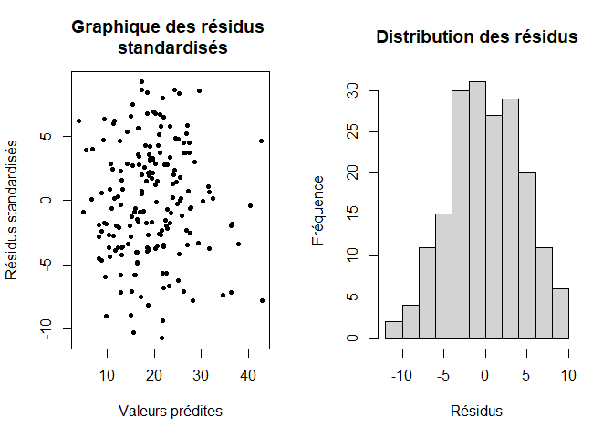

On observe que les résidus sont uniformément dispersés. Les résidus suivent une distribution normale. Le test de schapiro ci-dessous confirme cette affirmation car la p-valeur est supérieur à 0.05.

```
##
##  Shapiro-Wilk normality test
##
## data:  resid(ModelFinaleSiri)
## W = 0.98876, p-value = 0.1491
```

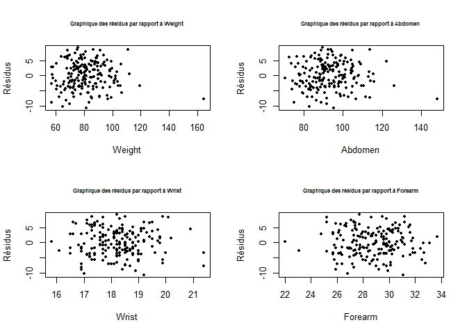

Il n’y a pas non plus de problèmes avec l’étude des résidus par rapport aux variables explicatives du modèle.

#### Nouvelle détection des points influents

```
## Potentially influential observations of
##   lm(formula = body.fat.siri ~ weight + abdomen + wrist + forearm) :
##
##     dfb.1_ dfb.wght dfb.abdm dfb.wrst dfb.frrm dffit   cov.r   cook.d  hat
## 24   0.00   0.01    -0.02     0.02    -0.01    -0.03    1.15_*  0.00    0.10_*
## 27  -0.65  -1.47_*   0.51    -0.11     1.51_*  -2.16_*  1.60_*  0.91_*  0.45_*
## 29   0.15   0.03    -0.08    -0.13     0.03    -0.23    1.09_*  0.01    0.08
## 117 -0.02   0.04    -0.06    -0.02     0.07     0.12    1.09_*  0.00    0.06
## 146 -0.04  -0.01    -0.04     0.10    -0.04    -0.12    1.11_*  0.00    0.08
## 159  0.41   0.48    -0.31    -0.24    -0.23    -0.53_*  0.96    0.06    0.06
## 162 -0.11   0.10    -0.07     0.10    -0.03    -0.30    0.90_*  0.02    0.02
## 163  0.35   0.28    -0.14    -0.17    -0.26    -0.43    0.90_*  0.04    0.03
## 164  0.02   0.00     0.00     0.00    -0.01     0.02    1.12_*  0.00    0.08
## 186 -0.24  -0.13     0.11     0.27    -0.08     0.31    1.08_*  0.02    0.08_*
```

#### Prédictions

```r
predictions_Siri <- predict(ModelFinaleSiri, newdata = data %>% select(c(weight,abdomen,wrist,forearm)))

predictions_Brozek <- predict(ModelFinaleSiri, newdata = data %>% select(c(weight,abdomen,wrist,forearm)))

predictions_Deurenberg <- (1.2*data$BMI) + (0.23 * data$age) - (10.8 * 1) - 5.4
```

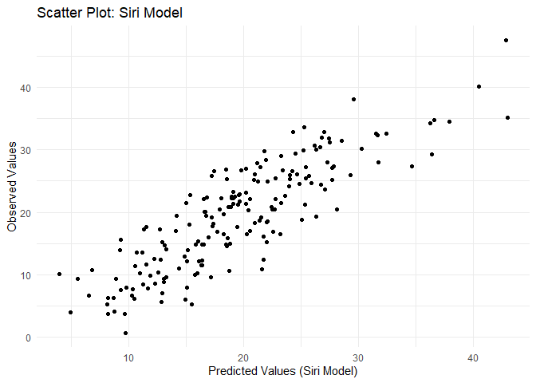

```r
# Add predictions to the dataset
data$predictions_Siri <- predict(ModelFinaleSiri, newdata = data %>% select(weight, abdomen, wrist, forearm))
data$predictions_Brozek <- predict(ModelFinaleBrozek, newdata = data %>% select(weight, abdomen, wrist, forearm))
data$predictions_Deurenberg <- (1.2 * data$BMI) + (0.23 * data$age) - (10.8 * 1) - 5.4

# Scatter plot of Siri model: Predicted vs Observed
ggplot(data, aes(x = predictions_Siri, y = body.fat.siri)) +
  geom_point() +
  labs(x = "Predicted Values (Siri Model)", y = "Observed Values") +
  ggtitle("Scatter Plot: Siri Model") +
  theme_minimal()
```

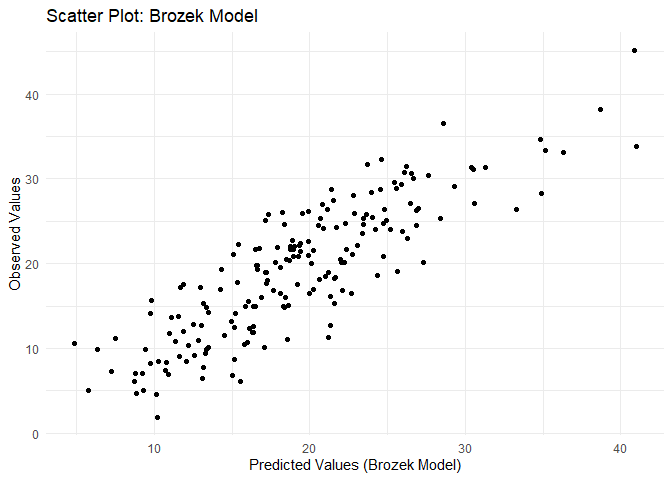

```r
# Scatter plot of Brozek model: Predicted vs Observed
ggplot(data, aes(x = predictions_Brozek, y = body.fat)) +
  geom_point() +
  labs(x = "Predicted Values (Brozek Model)", y = "Observed Values") +
  ggtitle("Scatter Plot: Brozek Model") +
  theme_minimal()
```

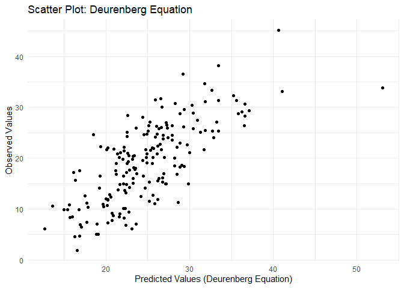

```r
# Scatter plot of Deurenberg equation: Predicted vs Observed
ggplot(data, aes(x = predictions_Deurenberg, y = body.fat)) +
  geom_point() +
  labs(x = "Predicted Values (Deurenberg Equation)", y = "Observed Values") +
  ggtitle("Scatter Plot: Deurenberg Equation") +
  theme_minimal()
```

On voit que les modèles de régression multiple sont plus performants que les équations généralisées, telles que celle de Deurenberg, pour prédire l’Indice de Masse Grasse.

## Nouvelle équation pour calculer l’IMG

L’équation du modèle de régression linéaire multiple de Brozek est : IMG = -31.71 + -0.3 weight + 0.93 abdomen + -1.51 wrist + 0.57 forearm

L’équation du modèle de régression linéaire multiple de Siri est : IMG = -35.67 + -0.32 weight + 1 abdomen + -1.61 wrist + 0.61 forearm

## Conclusion

### Conclusion statistique

Dans cette étude statistique de l’Indice de Masse Grasse (IMG), nous avons identifié des points influents et atypiques dans les observations. L’identification de ces points nous permet de comprendre les patterns et les comportements inhabituels des données, et ainsi d’éviter le biais des résultats de l’étude. Nous avons utilisé deux formules pour calculer l’IMG chez l’adulte : la formule de Brozek et la formule de Siri. Les variables d’intérêt étaient le pourcentage de masse grasse calculé avec ces deux formules (body.fat et body.fat.siri).

Après avoir nettoyé les données en calculant l’Indice de Masse Corporelle (IMC) et en supprimant les observations avec des différences, nous avons effectué des analyses descriptives univariées pour détecter les valeurs aberrantes. Les boxplots ont révélé la présence d’observations atypiques, mais nous ne les avons pas supprimées car nous ne savions pas si elles étaient influentes.

Ensuite, nous avons procédé à la détection des points influents et atypiques. Après avoir effectué différentes méthodes de détection des points influents ou atypiques, nous avons identifié et supprimé des observations en utilisant les méthodes suivantes afin d’améliorer la validité et la précision du modèle de régression :

La distance de Cook a été utilisée pour identifier les observations influentes sur l’estimation des paramètres du modèle. Les DFFITS ont été utilisés pour détecter les observations ayant une influence significative sur les prédictions du modèle. Les DFBETAS ont été utilisés pour repérer les observations ayant une influence significative sur les coefficients de régression. Les ratios de covariance (Cov.R) ont été utilisés pour évaluer l’impact des observations sur les variances et covariances des paramètres du modèle.

Pour mieux comprendre ces observations, nous avons analysé les résidus et leur impact sur les variances et covariances des coefficients du modèle. Nous avons également examiné les ratios de covariance pour évaluer l’impact des observations sur les variances et covariances des paramètres.

Après avoir effectué une analyse statistique de l’Indice de Masse Grasse (IMG) en utilisant la formule de Brozek, nous avons construit le modèle de régression linéaire multiple complet pour expliquer la variation de l’IMG en fonction de différentes variables explicatives comprises dans le dataset telles que l’âge, le poids, le cou, l’abdomen, la cuisse, l’avant-bras et le poignet.

La qualité d’ajustement du modèle, mesurée par le coefficient de détermination R² (0,75) et le coefficient de détermination ajusté R² ajusté (0,73), indiquait que le modèle explique une grande partie de la variance de l’IMG. Ces valeurs suggèrent un bon ajustement du modèle aux données.

Ensuite, nous avons évalué la contribution globale des variables explicatives à l’explication de l’IMG en effectuant un test de comparaison de modèles. Le test a confirmé que le modèle complet, comprenant toutes les variables explicatives, est significativement meilleur qu’un modèle n’incluant pas de variables explicatives, ce qui indique que les variables contribuent de manière significative à l’explication de l’IMG.

Nous avons également utilisé différentes méthodes de sélection de variables, telles que la méthode exhaustive et la méthode pas à pas, pour identifier les variables les plus pertinentes dans le modèle. Parmi les modèles retenus, nous avons sélectionné le modèle comprenant le poids, l’abdomen, le poignet et l’avant-bras comme le meilleur modèle final en raison de son ajustement et de l’absence de colinéarité entre les variables.

En ce qui concerne la validation du modèle, nous avons effectué un diagnostic des résidus pour vérifier les hypothèses de normalité et d’homoscédasticité. Les résidus semblent suivre une distribution normale et sont uniformément dispersés, ce qui confirme la validité du modèle.

En conclusion, notre modèle de régression linéaire multiple, comprenant les variables poids, abdomen, poignet et avant-bras, offre une bonne explication de la variation de l’Indice de Masse Grasse.

L’équation du modèle de régression linéaire multiple de Brozek est : IMG = -31.71 + -0.3 weight + 0.93 abdomen + -1.51 wrist + 0.57 forearm

L’équation du modèle de régression linéaire multiple de Siri est : IMG = -35.67 + -0.32 weight + 1 abdomen + -1.61 wrist + 0.61 forearm

### Conclusion non statistique

En conclusion, notre étude nous a permis de développer un modèle statistique solide pour prédire l’Indice de Masse Grasse (IMG) en utilisant des variables explicatives pertinentes. Grâce à l’utilisation de variables telles que le poids, l’abdomen, le poignet et l’avant-bras, nous sommes en mesure de prédire avec précision les variations de l’IMG chez les individus.

Ce modèle offre une compréhension approfondie de la relation entre ces variables explicatives et l’IMG, ce qui est essentiel pour évaluer la composition corporelle et la santé globale. En utilisant les données disponibles, nous pouvons prédire l’IMG d’une personne en connaissant ces variables explicatives.

Ce modèle est basé sur une analyse statistique rigoureuse et utilise des méthodes de détection des points influents et atypiques pour garantir sa validité et sa précision. Les résultats obtenus ont montré que le modèle explique une grande partie de la variance de l’IMG, ce qui renforce sa capacité prédictive.

Quel est l’intêret de réaliser des modèles comme ceux-ci, au lieu d’utiliser des équations dejé existantes ?

La réalisation de modèles statistiques spécifiques permet d’adapter les prédictions aux données disponibles, d’identifier les variables les plus pertinentes, d’évaluer la validité et la précision du modèle, d’améliorer la compréhension du phénomène étudié et de permettre une amélioration continue en fonction des nouvelles données. Cela offre une approche personnalisée et précise pour prédire et comprendre les phénomènes, ce qui est essentiel dans de nombreux domaines. L’étude a également démontré que les modèles de régression multiple sont plus performants que les équations généralisées, telles que celle de Deurenberg, pour prédire l’Indice de Masse Grasse.

L’équation du modèle de régression linéaire multiple de Brozek est : IMG = -31.71 + -0.3 weight + 0.93 abdomen + -1.51 wrist + 0.57 forearm

L’équation du modèle de régression linéaire multiple de Siri est : IMG = -35.67 + -0.32 weight + 1 abdomen + -1.61 wrist + 0.61 forearm